# The structure of plant–herbivore interaction networks varies along elevational gradients in the European Alps - Pitteloud - - Journal of Biogeography - Wiley Online Library

[Journal of Biogeography](https://onlinelibrary.wiley.com/journal/13652699)

[Early View](https://onlinelibrary.wiley.com/toc/13652699/0/0)

[figure not shown]

RESEARCH PAPER

Full Access

# The structure of plant–herbivore interaction networks varies along elevational gradients in the European Alps

[Camille Pitteloud](https://onlinelibrary.wiley.com/action/doSearch?ContribAuthorStored=Pitteloud%2C+Camille)

[Jean‐Claude Walser](https://onlinelibrary.wiley.com/action/doSearch?ContribAuthorStored=Walser%2C+Jean-Claude)

[Patrice Descombes](https://onlinelibrary.wiley.com/action/doSearch?ContribAuthorStored=Descombes%2C+Patrice)

[Charles Novaes de Santana](https://onlinelibrary.wiley.com/action/doSearch?ContribAuthorStored=Novaes+de+Santana%2C+Charles)

[Sergio Rasmann](https://onlinelibrary.wiley.com/action/doSearch?ContribAuthorStored=Rasmann%2C+Sergio)

[Loïc Pellissier](https://onlinelibrary.wiley.com/action/doSearch?ContribAuthorStored=Pellissier%2C+Lo%C3%AFc)

First published: 06 December 2020

https://doi.org/10.1111/jbi.14014

Handling Editor: Evan Economo

## Abstract

### Aim

Ecological gradients are expected to be associated with structural rewiring of species interaction networks. The study of network structures along geographic and ecological gradients, however, remains marginal because documenting species interactions at multiple sites is a methodological challenge. Here, we aimed to study the structural variation in plant–herbivore interaction networks along elevational gradients using molecular metabarcoding.

### Location

European Alps.

### Taxon

Plant and Orthopteran herbivores.

### Methods

We used a standardized DNA metabarcoding method applied to Orthopteran faeces to document the structure of 48 networks of species interactions across six elevational gradients. We examined how structural properties of plant–Orthoptera networks reflecting specialization and robustness vary with elevation. We compared observed variation to null models to account for differences in network size.

### Main conclusions

In cold environments, plant–herbivore networks are wired in a way that may reinforce the resilience of the system to species extinction. Documenting ecological networks along ecological gradients allows a better understanding of the influence of climate on the structure of ecological communities.

## 1 INTRODUCTION

Species represent the main building blocks of ecosystems and are connected in webs of positive and negative interactions, which shape ecosystem processes and functioning (Thompson et al., 2012). Given the central role of interactions among species for energy and matter flow between ecosystem compartments (Barnes et al., 2018), studying the structure of ecological networks helps us understand how ecosystem functioning might be disrupted by global changes (Petchey et al., 1999; Tylianakis et al., 2008). The wiring among interacting species is hardly random but rather governed by ecological rules (Bascompte, 2010; Laigle et al., 2018). The occurrence and strength of interactions between species may depend on the degree of matching between functional traits, which are shaped by co‐evolutionary processes (Laigle et al., 2018; Rausher, 2001; Segar et al., 2020). In turn, rules of functional matching might be influenced by the variation in environmental conditions, such as temperature (Gounand et al., 2016; Sentis et al., 2014), or by climatic stability (Dalsgaard et al., 2011). By influencing changes in species composition, ecological gradients can be associated with shifts in species co‐occurrence and their ability to form stable links (Pellissier et al., 2018; Welti & Joern, 2015). Moreover, shifting environmental conditions might influence interactions among species even when they are steadily co‐occurring (Tylianakis & Morris, 2017). As a result, interaction shifts along climatic clines can lead to changes in the structure of networks (Welti & Joern, 2015). Nevertheless, the geographic variation in networks is poorly studied, owing to the difficulty of documenting multiple ecological networks along climatic gradients.

There are major challenges to the large‐scale study of ecological networks that relate to the documentation of interactions and the methods used to perform network comparisons at the landscape scale (Pellissier et al., 2018). The study of ecological networks along environmental gradients has so far been limited by the difficulty of observing comparable interactions simultaneously at multiple locations. Novel DNA metabarcoding methods, which are increasingly cheaper, faster and more comprehensive, have opened such opportunities (Kaartinen et al., 2010; Roslin et al., 2019). Deagle et al. (2007) were among the first to develop a DNA metabarcoding protocol to reconstruct the trophic regime of the macaroni penguins on Heard Island in the Indian Ocean. Since then, the study of entire ecological networks has been facilitated through the adaptation of DNA metabarcoding techniques to different sample sources, which enables the collection of many samples over a short period of time (Roslin et al., 2019). For instance, Pornon et al. (2016) developed a protocol to quantify plant–pollinator interactions from pollen samples in the French Central Pyrenees, while Ibanez, et al. (2013) applied this approach to insect faeces for studying the diet of insect herbivores. However, most protocols for network reconstruction were not designed for studies with large spatial scales, and not all were aimed at species‐level resolution. In addition, a complete description of the wet‐lab and bioinformatic procedures is not always accessible, limiting the adaptability and reproducibility of the techniques used to document species interactions. Scaling up the utilization of DNA metabarcoding to entire landscapes, while also sharing methodological workflows as detailed and user‐friendly protocols, can spur advances in the study of species interactions along environmental gradients.

From the wide range of natural gradients impacting species distribution and interaction patterns, montane clines represent optimal natural laboratories to understand how species and their interactions vary over environmental gradients (Körner, 2003). Changes in climate – most notably temperature – along elevational gradients cause strong environmental filtering in communities (Hodkinson, 2005; Rahbek, 1995) and can therefore also be expected to influence the structure of ecological networks (Maunsell et al., 2015; O’Connor et al., 2009; Rodríguez‐Castañeda et al., 2010; Welti & Joern, 2015). The structure of ecological networks along environmental gradients can change as a result of two main processes: (a) a turnover of the species in the network, or (b) a turnover of the links in the network, in which co‐occurring species rewire their interactions along the gradient (Gravel et al., 2019). In particular, the steady decrease in temperature with increasing elevation has been associated with changes in species richness and abundance (Descombes et al., 2017; Hodkinson, 2005; Rahbek, 1995), likely influencing the networks of species interactions (Adedoja et al., 2018; Pellissier et al., 2018). Therefore, studying changes in the architecture of species networks along elevational gradients contributes to evaluations of the effect of temperature on community structure and stability.

Changes in species’ interactions within networks can be summarized by a set of indicators relating to the degree of structuration and complexity of the network (Delmas et al., 2019), including connectance (Martinez, 1992), generality (Bersier et al., 2002), nestedness (Bascompte et al., 2003) and robustness (Dunne et al., 2002). Metrics of network structure can also quantify the resilience of the networks to environmental disturbances (Thebault & Fontaine, 2010). For instance, specialized networks have been found to be associated with lower robustness against species extinction (Lafferty & Kuris, 2009; Tylianakis & Morris, 2017; but see May, 1973; McCann, 2000). This is the result of the existence of keystone species (Paine, 1969), which are nodes of interactions on which relies the system's stability (Power et al., 1996). The importance and identity of keystone species, but also general structural properties involved in network resilience, may reshuffle along elevation clines. Three main non‐exclusive hypotheses have been proposed to support this pattern: (a) at higher elevations the environment is expected to be less predictable (Barry, 2008), and survival under these conditions necessitates the evolution of a broader diet breadth (Macarthur & Levins, 1967); (b) more intense competition at low elevations is predicted to select for more specialized diets to decrease niche overlap (Hodkinson, 2005; Macarthur & Levins, 1967); and, more closely linked to plant–herbivore interactions, (c) a decline in the capacity of plants to resist herbivore attack at higher elevations is expected to facilitate a larger diet breadth of herbivores (Moreira et al., 2018; Pellissier et al., 2012,2012; Rasmann et al., 2014). Moreover, the relaxation of predation pressure at higher elevation could also influence diet choice in herbivores (Rasmann et al., 2013). In contrast to the expectation of increased herbivore generality at higher elevations, where plant communities are less diverse, it has been proposed that higher plant species richness could benefit insect generalists simply by increasing the availability of species to feed on (Unsicker et al., 2008; Welti et al., 2017).

The comparison of ecological networks along environmental gradients has the inherent methodological difficulties of network comparison (Pellissier et al., 2018). Effective analyses of network structure isolate the influence of real interaction patterns on network structural indices from the effects of network size or sampling design (Banašek‐Richter et al., 2004). Studying ecological networks along large‐scale environmental clines is challenging in this regard, because ecological clines are associated with changes in species richness, in turn affecting measures of structural indices sensitive to network size (Pellissier et al., 2018; Trøjelsgaard & Olesen, 2016). For instance, the number of links per species inevitably declines from large to small networks, as larger networks include more possible links. Several strategies have been developed to alleviate the confounding effects of comparing networks of different sizes (see Pellissier et al., 2018 for a review of these approaches). The most commonly used approach is the use of null models, where networks of randomly distributed interactions are generated and compared with the empirical patterns. This method has been established to isolate the role of observed interaction patterns on the network structure from the effect of network size variation when comparing networks along environmental gradients (Vázquez & Aizen, 2003).

In this study, we investigated the variation in the structure of plant–Orthoptera ecological networks along elevational gradients. Orthoptera are among the most abundant herbivorous arthropods in semi‐natural grasslands of the European Alpine system, and they strongly impact the functioning of these ecosystems (Blumer & Diemer, 1996). We optimized a protocol for plant DNA metabarcoding applied to Orthopteran faeces in order to reconstruct 48 plant–Orthoptera bipartite networks across 48 study sites situated along six elevational gradients in the Swiss Alps. We then applied null models to explore the structural variation in plant–Orthoptera bipartite networks and determine if lower levels of network organization and increased robustness are associated with the low temperatures of the alpine environments. We focused on metrics of generality and robustness, as those metrics are expected to strongly respond to shifts in environmental stability, competition and plant defences along elevation (Pellissier et al., 2012; Rasmann et al., 2013). Specifically, we proposed the following three main expectations:

1. Orthoptera are overall generalists, but their level of generality should increase towards higher elevation according to the following lines of argument: generalist feeders are better equipped to compensate for higher environmental uncertainty; lower interspecific competition attenuates positive selection for specialization; and the reduced plant chemical defences typically found at higher elevations offer more dietary opportunities for insects.
2. The robustness of the network after simulated plant primary extinctions should be higher at higher elevations. The increase in insect generalist feeding behaviour predicted in the first hypothesis should allow networks of alpine communities to better compensate for possible plant species loss.
3. If more generalist insect herbivores are present and the network is more robust at higher elevations, the removal of plant species should induce fewer extinctions within Orthopteran communities than at lower elevation, so that plants at higher elevations have lower keystone weights.

## 2 MATERIALS AND METHODS

### 2.1 Field data collection

To study variation in the plant–insect trophic network with elevation, in 2016, we sampled 48 sites along six elevation transects, with the quantification of one network per site. Sampled sites covered the diversity of environmental conditions of the Swiss Alps, differing in local climate and bedrock – that is, in the areas of Bex, Calanda, Faido, Grindelwald, Martigny and Salgesch (Supporting information, Appendix S1, Figure S1). Each gradient was divided into eight sites, spanning elevations from 578 to 2,417 m a.s.l., located on average 240 m of elevation apart from each other. Sites were chosen to be open grasslands with a limited impact from anthropogenic activities. At each site, we defined a 10 m × 10 m survey plot representative of the homogeneous composition of the surrounding vegetation. Orthopteran surveys were conducted under sunny weather conditions during the summer at insect peak activity times. We focused on Caelifera and Ensifera suborders that are known to feed on living plant material (Baur et al., 2006). We identified Orthoptera by visual inspection, caught on average 10 individuals per species, kept them in falcon tubes for c. 2 hr, for collecting faecal excretions, before releasing them again all at once. We performed the vegetation surveys in a 9 m<sup>2</sup> circular plot located in the most homogeneous zone of the 100 m<sup>2</sup> plot and searched for additional rare species within the 100 m<sup>2</sup> plot. We used temperature as the main environmental variable that changed along the elevational gradient (Appendix S1, Figure S2). Soil temperature data were collected for half of the sites per transect using temperature loggers (DS1921G‐F5 HomeChip, Newton Longville, England) that were parameterized at a 0.5°C resolution with a sampling rate of 240 min, wrapped in parafilm, protected by a silicone capsule and buried 4 cm deep in the ground at each site (from October 2017 to October 2018). Summer soil temperature was extrapolated for unmonitored sites by linear regression (Appendix S1, Figure S3). To study the keystone plant species, in 2017, we measured plant functional traits that related to physical resistance or nutrient content: specific leaf area (SLA), leaf dry matter content (LDMC), force required to pierce the leaf lamina (punch), and carbon‐to‐nitrogen ratio (C/N). We sampled well‐developed, healthy leaves to measure the traits of all species with a minimum of three replicates across their elevation range (76% of the total number of surveyed species). SLA and LDMC were measured using standard procedures (Pérez‐Harguindeguy et al., 2013). Punch was calculated using a digital force gauge (IMADA CO., LTD. Toyohashi, Japan), following Sanson et al. (2001). C/N was determined by dry combustion of ground leaf material (4mg ± 0.2mg) of intraspecific replicates pooled to equal weight using an elemental analyser (NC‐2500 from CE Instruments). The collection of trait data was completed with published datasets (Descombes et al., 2017; Kattge et al., 2011; Körner et al., 2016).

#### 2.1.1 Plant–Orthoptera network reconstruction

The reconstruction of plant–insect trophic networks from faecal samples relies on a DNA metabarcoding procedure that uses a two‐step DNA amplification PCR‐based approach in which samples are individually tagged by dual indexing. A full protocol of the wet‐lab procedure, from DNA extraction to sequencing, is provided in Supporting information, Appendix S2, section Methods 1. In short, after DNA extraction from the insect faeces, the ITS2 nuclear plant marker (360 bp) was amplified in the amplicon PCR. We selected this marker based on its ease of amplification, high taxonomic resolution, good coverage of the reference database and successful application to degraded DNA samples (García‐Robledo et al., 2013; Li et al., 2011). In parallel to DNA metabarcoding library preparation and sequencing, we compiled an ITS2 reference database by recovering sequences from Genbank (Clark et al., 2016). The database was filtered using in‐silico PCRs that allow only one mismatch between the primers and the priming sites. We expanded the reference database with custom sequences generated for 54% of the plant species (see Appendix S2, section Methods 2). After processing of the raw sequencing data, OTU calling and taxonomic assignment against the DNA reference database, the OTU table was streamlined to reconstruct individual networks using R (R Core Team, 2019; see complete descriptions of the bioinformatic and OTU table cleaning procedures in Appendix S2, section Methods 3). We discarded OTUs that were non‐monophyletic and/or identified above the family level, summed the OTUs belonging to the same taxon, used vegetation surveys to filter out the OTUs with low read numbers, and redistributed the count of OTUs assigned above the species level. In a final step, we computed the relative read abundance (RRA) for each sample as an estimate of the interaction intensity (Deagle et al., 2019; Roslin et al., 2019).

#### 2.1.2 Statistical analyses of variation in network metrics

We computed network metrics using the R package *bipartite* (Dormann et al., 2008). We considered the number of links per species, calculated as the total number of links divided by the total number of species. The generality index, which estimates the mean number of plant species per Orthopteran species weighted by the marginal counts (Bersier et al., 2002) and is calculated from the presences and absences of interactions instead of their intensities. The robustness of the networks (Dunne et al., 2002), which involves calculating the cumulative proportion of secondary extinctions caused by the sequential removal of plant species until all insect species are extinct. As implemented in *bipartite*, the function uses a quantitative estimation of the robustness introduced by Burgos et al. (2007). It measures the area under the attack tolerance curve (ATC), which describes the relationship between the proportion of species removed and the proportion of surviving insect species, until all species are extinct. The sequential species removal was done randomly for 100 replicates, excluding plant taxa that were not ingested. We finally computed the weighted nestedness following Galeano et al. (2009), as it has been associated with network robustness (Bascompte et al., 2003). Relationships between mean summer temperature and the observed network metrics were tested using linear mixed effects models including transect identity as a random factor (packages *lme4* Bates et al., 2008 and *lmerTest* Kuznetsova et al., 2017). We used a null model approach to discriminate the effect of the non‐random interactions on the metric from the influence of inherent bias of network metric calculation (e.g. network size). We generated 999 random metawebs, where interactions were fully randomized and impossible links excluded. Individual random networks were then reconstructed for each study site according to their species composition. We further measured network properties for each network and metric variation along the gradient, following the same procedure as applied for the observed networks. Statistical significance of the metric variation was confirmed if the observed slope of the relationship between the temperature and the network metric fell outside the 2.5%–97.5% quantile interval of the slopes obtained for the randomized network of interactions. We also calculated the standardized effect size (SES) to quantify the difference between the observed relationships and the null models. The approach we used here does not suppress the metrics’ sensitivity to sampling effects, but slope values outside the 2.5%–97.5% quantile interval of the slopes obtained from random networks (and large values of SES) indicate that the interactions of empirical networks contribute more to the metric variation along the gradient than expected by chance.

#### 2.1.3 Identification of keystone species

Keystone species are defined here as the plant taxa that play a major role in providing a food source for the Orthopteran herbivores (Mills et al., 1993; Power et al., 1996). We identified keystone species using custom R scripts, submitting each network, preliminarily transformed into an igraph object (Csardi & Nepusz, 2006), to a sequential and random removal of plant species. Insect species were considered to be extinct upon loss of all the plant species they feed on. Plant species were removed until all insect species became extinct. This was repeated for n*(n–1) simulations, with n equalling the total number of plant taxa in the network. The mean number of secondary extinctions caused by plant removal, to which we refer hereafter as the keystone score, was then calculated for each plant species. To examine the distribution and the keystone score of species within the plant functional space at the low (<1,050 m a.s.l.) and high elevation (>2000 m a.s.l.), we performed a principal components analysis on plant traits with the function dudi.pca from the ade4 package (Thioulouse et al., 2018). We compared the distribution of species with different keystone scores in the functional space of plant traits of species at the lowest and highest elevation sites. For both elevation classes, we extracted plant species based on their presence within the corresponding elevation range. We further determined the 10 species with the highest keystone scores for each network, averaged their weights for each elevation class and placed them in the functional space of plant traits.

## 3 RESULTS

### 3.1 Field surveys and network reconstruction

**FIGURE 1**

#### 3.1.1 Variation in network metrics

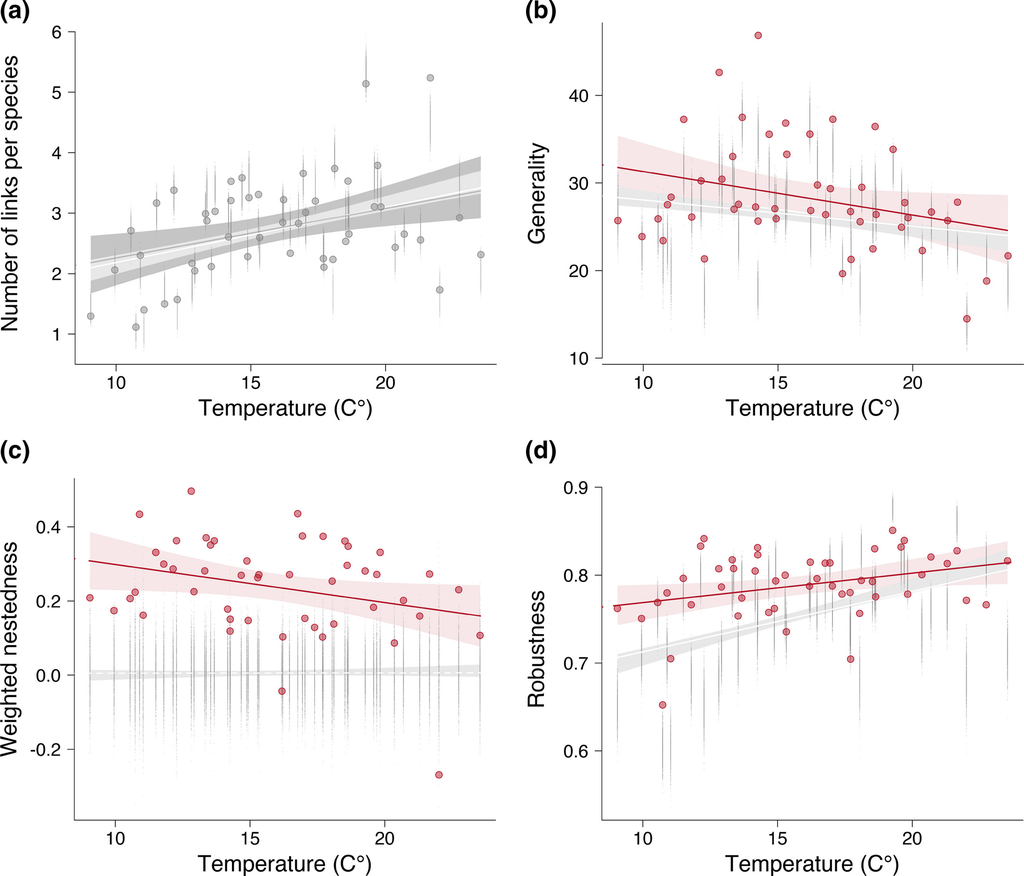

**FIGURE 2**

Relationship between the mean summer temperature at each site along the elevational gradients and plant–Orthoptera network metrics: number of links per species (a), network generality (b), weighted nestedness (c) and network robustness (d). Regression lines result from linear mixed effects models, where solid lines indicate a significant relationship between the observed or random network metrics and the temperature. Expected metrics based on null models are represented in light grey with a white regression line. When the slope of the empirical relationship is outside the 2.5%–97.5% quantile interval of the slopes obtained from random networks, the regression line and metric values are red, while they are dark grey when the observed slope is not outside the slope interval expected from null models. The confidence interval of the temperature versus metric relationship is shown for observed metrics and the null models

TABLE 1. Coefficients obtained for the observed metric variation along the temperature gradient and the null models. For each metric, the slope of the relationship between the observed metric and the temperature, the intercept estimate, the *p* value (*p*), the degrees of freedom (*df*), the t‐value, the standardized effect size (SES) measured between the observed metric slopes and those obtained from random networks of interactions, and the 2.5% and 97.5% quantile interval limits of the slopes obtained for random networks are given. For generality, weighted nestedness and robustness, observed slopes were found outside the 2.5% and 97.5% quantile interval limits obtained with null models

|  | Slope Estimate | Intercept Estimate | *p* | *df* | t‐value | SES | 2.5% quantile | 97.5% quantile |
| --- | --- | --- | --- | --- | --- | --- | --- | --- |
| Number of links per species | 0.0819 | 1.44 | .003 | 42.56 | 3.20 | −1.82 | 0.0816 | 0.1032 |
| Generality | −0.4973 | 36.28 | .035 | 43.66 | −2.17 | −3.44 | −0.4066 | −0.1868 |
| Weighted nestedness | −0.0102 | 0.40 | .042 | 43.91 | −2.10 | −3.51 | −0.0054 | 0.0060 |
| Robustness | 0.0033 | 0.74 | .023 | 43.62 | 2.06 | −5.77 | 0.0057 | 0.0082 |

#### 3.1.2 Keystones species in the functional space of plant traits

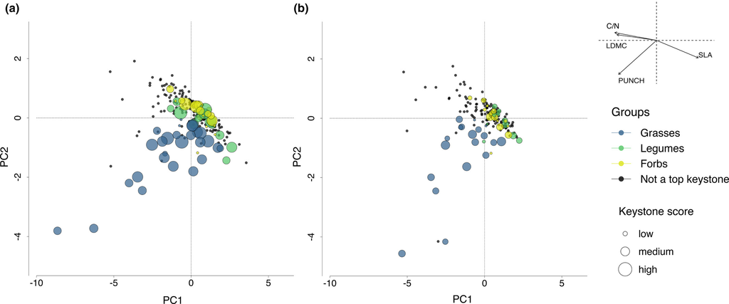

**FIGURE 3**

Distribution of keystone species in the functional space of the plant traits between low‐ (a, <1,050 m a.s.l.) and high‐elevation (b, >2000 m) plant communities. Plant species are projected onto the first two axes of the principal components analysis (PCA) performed on plant functional traits, which explain 58.8% (PC1) and 15.6% (PC2) of the variance. The top 10 keystone species are coloured by plant taxonomic group, while all other species are shown in black. The keystone score corresponds to the mean number of secondary extinctions caused by the removal of the plant species. It varies between 0.12 and 0.75 secondary extinctions across all networks but is summarized in the legend as three circle sizes (low, medium and high). Correlations between plant functional traits (C/N, LDMC, punch and SLA) and the two first axes of the PCA are given in the plot in the top right corner

## 4 DISCUSSION

Compared with traditional methods based on visual analyses of faeces or gut content, or literature‐based documentation of interactions (Nielsen et al., 2018), the DNA metabarcoding procedure represents an effective and easily adaptable method for documenting interactions involving plants and insect species. As a compromise between the spatial coverage of our study and the available sampling resources, potential impacts of sampling replication and seasonality and year‐to‐year change on diet composition were not assessed here (Mata et al., 2019). Overall, our approach may open fields of investigation on the possible spatio‐temporal variation in plant–insect interactions by expanding the means for collecting species interaction data.

Taken together, our results show an increase in plant–herbivore network generality and nestedness with elevation, which drives variation in network robustness along the gradient and ultimately gives lower weights to keystone species in alpine than in lowland environments. Shifts in abiotic components can alter the structuring of species interactions directly or indirectly (Tylianakis & Morris, 2017; Welti & Joern, 2015), by influencing the different aspects of the species interface through both abiotic and biotic pressures. We suggest that the observed patterns of network structural variation regarding elevation represent entangled responses of networks to environmental predictability and plant chemical defences, although further investigation would be required to confirm this possibility. Generally, Orthoptera are not very sensitive to extinction, in that the loss of multiple plant species is necessary to cause secondary extinctions. Nevertheless, intensification of land use practices in lower‐elevation mountain grasslands, for instance through the use of fertilizers, can regularly cause the loss of multiple plant species, which could then lead to extinctions in Orthoptera (Chisté et al., 2016). Our study helps pave the way to a better understanding of the eco‐evolutionary factors underlying network structure along large‐scale ecological gradients, but also highlights how resilient species assemblages are to the accelerated rate of species extinction.

## ACKNOWLEDGEMENTS

We are deeply grateful to our collaborators at the Genetic Diversity Centre (GDC) at ETH Zurich, in particular to Silvia Kobel and Aria Minder for their assistance in producing and analysing the data used in this study. A special thanks to Christian Roesti and Maude Poirier for their help in the field. For their assistance in data collection, we thank Giulia Donati, Fabian Fopp, Joan Casanelles Abella, Marie‐Angèle Pitteloud, Nico Baetz, Nadine Sandau. Thanks also to Camille Albouy, Gabriel Dettling, Daniele Pezzotta, Marco Lanfranchi, Janka Bollenbach, Angéline Bedolla, Alain Reymond, Jean‐Nicolas Pradervand, Glenn Litsios, Antoine Guisan and Nicolas Salamin. This work was funded by the National Swiss Fund for research (grants 162604 to LP, 31003A_179481 to SR, 31003A‐125145 to Antoine Guisan).

## Open Research

## Supporting Information

## REFERENCES

## BIOSKETCH

**Camille Pitteloud** completed a PhD in the group of Landscape Ecology at ETH Zürich and WSL in network ecology by studying plant–herbivore interactions to identify structural variation of trophic networks along the elevation. Her work contributes to a deeper understanding of how climatic factors may influence ecological network structuration across broad spatial scales.

Author contributions: CP, LP and SR conceived and designed the study, and wrote the manuscript text with input from all authors. CP, LP and PD contributed to data collection. CP, JCW, CNS and LP analysed the data. All authors reviewed and contributed to the manuscript.

[figure not shown]

Online Version of Record before inclusion in an issue

### Metrics

### Details

[figure not shown]

### Keywords

  - [DNA metabarcoding](https://onlinelibrary.wiley.com/action/doSearch?field1=Keyword&text1=DNA%20metabarcoding)
  - generality
  - [keystone species](https://onlinelibrary.wiley.com/action/doSearch?field1=Keyword&text1=keystone%20species)
  - nestedness
  - [null models](https://onlinelibrary.wiley.com/action/doSearch?field1=Keyword&text1=null%20models)
  - robustness
  - [trophic networks](https://onlinelibrary.wiley.com/action/doSearch?field1=Keyword&text1=trophic%20networks)

### Funding Information

  - Schweizerischer Nationalfonds zur Förderung der Wissenschaftlichen Forschung. Grant Numbers: 162604, 31003A‐125145, 31003A_179481

### Publication History

  - Version of Record online: 06 December 2020
  - Manuscript accepted: 04 October 2020
  - Manuscript revised: 29 September 2020
  - Manuscript received: 25 May 2020